# Midterm Data Exercise #1 - Continuous Outcomes

## Question 5 - Interpreting the Subset Model (8 pts.)

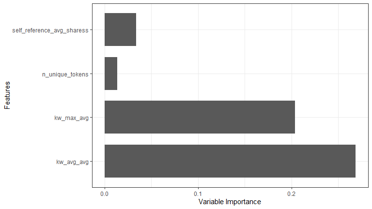

```r
# plot the variable importance
bestM <- ranger(data = train_df_4RFvar, formula = shares ~ .,
    mtry = 4, num.trees = 1000, importance = "permutation")
p5_df <- data.frame(bestM$variable.importance)
p5_df$var <- rownames(p5_df)
p5_df <- p5_df %>%
    rename(var_imp = bestM.variable.importance)
ggplot(data = p5_df, aes(x = var, y = var_imp)) + geom_bar(stat = "identity",
    width = 0.75) + coord_flip() + labs(x = "Features", y = "Variable Importance") +
    theme_bw()
```

```r
p5_df %>%
    arrange(desc(var_imp))
```

|  | var_imp | var |
| --- | --- | --- |
| kw_avg_avg | 0.2688125 | kw_avg_avg |
| kw_max_avg | 0.2037866 | kw_max_avg |
| self_reference_avg_sharess | 0.0336224 | self_reference_avg_sharess |
| n_unique_tokens | 0.0135903 | n_unique_tokens |

```r
# variables: kw_avg_avg/ self_reference_avg_sharess
# /kw_max_avg / n_unique_tokens bestModel
```

From question 4, we choose random forest model for good prediction performance, while we sacrifice the interpretability of the model. With our best model on our selected variables, we could only tell the importance of each selected variables shown above. We could see that the Avg. keyword (max. shares)[kw_max_avg] and Avg. keyword (avg. shares)[kw_avg_avg] takes a huge part of the variable importance, while the model also suugests some importance on Avg. shares of referenced articles in Mashable [self_reference_avg_sharess] and Rate of unique words in the content [n_unique_tokens]. The result is quite similar with what we got in the full model: all of our four varibels in Q4 are also in the top 8 importance of the full model; 3 out of 4 are the most importance among all variables in full model.

Since random forest doesn’t return any coefficient as the linear models do, we don’t really know for sure whether these variables are positively OR negatively correlate to the outcome[shares]. With our best educational guess, we might take a conjecture that highest number of shares articles will be those which: 1) keywords with good amount of shares(both top number of shares and average number of shares) in the past; 2) reference on high-shares articles; 3) using good amount of high rate unique words. The lowest number of shares articles will be those don’t do well on our conjecture.

Actionable rules: 1) have a good idea about popular “keywords” on Mashable and use those keywords as frequent as possible.If not sure what are those “keywords”, use diverse vocabulary so that you will hit some by chance. 2) include reference to the popular articles on Mashable. If not sure about what’s the *most popular ones, maybe refer to as many articles as possible such that you will somehow hit one. 3) use unique vocabulary with huge diversity.

why we not expect the rule set makes sense: There are many confounding variables that we are unable to include in our model. For example, the recommend-article-to-reader algorithm might have bias on some types of articles and thus recommend those articles more frequently. In this way, those articles with high exposure to the public will naturally have larger audiences group and higher amount of shares.

## Question 6 - Building a Predictive Model with a Single Predictor (15 pts.)

### Initial sampling and recoding

```r
# sample training dataset
set.seed(456)
sam_train_p6 <- as.numeric(sample(x = nrow(train_df), size = 30000,
    replace = FALSE))
sam_test_p6 <- setdiff(seq(1, 35000, 1), sam_train_p6)
strain_df_p6 <- train_df[sam_train_p6, ]
stest_df_p6 <- train_df[sam_test_p6, ]

# transform variable shares
strain_df_p6$shares <- log(strain_df_p6$shares)
stest_df_p6$shares <- log(stest_df_p6$shares)

# drop variable url
strain_df_p6 <- strain_df_p6[, -1]
stest_df_p6 <- stest_df_p6[, -1]
```

### KNN

```r
# out-of-sample
knn_p6_mse_out <- c()
optimalk <- c()
variableIndex <- c()
# test for all 59 variables
knn <- seq(5, 1000, 50)
for (j in 1:59) {
    knn_mse_out_k <- c()
    for (i in knn) {
        # choose k for each variable
        knn_model_k <- knn.reg(train = as.data.frame(strain_df_p6[,
            j]), test = as.data.frame(stest_df_p6[, j]), y = as.data.frame(strain_df_p6[,
            60]), k = i)
        knn_mse_out_k <- c(knn_mse_out_k, mse(knn_model_k$pred,
            stest_df_p6$shares))
    }
    knn_p6_m <- knn.reg(train = as.data.frame(strain_df_p6[,
        j]), test = as.data.frame(stest_df_p6[, j]), y = as.data.frame(strain_df_p6[,
        60]), k = knn[which.min(knn_mse_out_k)])
    optimalk <- c(optimalk, knn[which.min(knn_mse_out_k)])
    variableIndex <- c(variableIndex, j)
    knn_p6_mse_out <- c(knn_p6_mse_out, mse(knn_p6_m$pred, stest_df_p6$shares))
}
p6_knn_out_df <- data.frame(var = colnames(strain_df_p6[, -60]),
    knn_p6_mse_out)
p6_knn_out_df %>%
    arrange(knn_p6_mse_out)
```

| var | knn_p6_mse_out |
| --- | --- |
| kw_avg_avg | 0.8152503 |
| kw_max_avg | 0.8202457 |
| self_reference_avg_sharess | 0.8352671 |
| LDA_02 | 0.8371018 |
| self_reference_max_shares | 0.8439601 |
| self_reference_min_shares | 0.8456361 |
| kw_min_avg | 0.8465696 |
| LDA_03 | 0.8467653 |
| global_subjectivity | 0.8520027 |
| LDA_01 | 0.8525168 |
| num_imgs | 0.8545199 |
| data_channel_is_world | 0.8574861 |
| LDA_04 | 0.8591278 |
| num_hrefs | 0.8598888 |
| timedelta | 0.8604265 |
| kw_max_min | 0.8637552 |
| is_weekend | 0.8643555 |
| LDA_00 | 0.8654145 |
| global_rate_positive_words | 0.8659581 |
| global_sentiment_polarity | 0.8660236 |
| n_tokens_content | 0.8663629 |
| kw_min_max | 0.8665002 |
| avg_positive_polarity | 0.8665504 |
| min_positive_polarity | 0.8668753 |
| kw_avg_min | 0.8669698 |
| title_subjectivity | 0.8672078 |
| title_sentiment_polarity | 0.8676969 |
| abs_title_sentiment_polarity | 0.8681415 |
| data_channel_is_entertainment | 0.8684778 |
| max_positive_polarity | 0.8685129 |
| n_non_stop_words | 0.8690008 |
| rate_positive_words | 0.8692429 |
| num_videos | 0.8694378 |
| weekday_is_sunday | 0.8694493 |
| data_channel_is_socmed | 0.8694713 |
| num_keywords | 0.8698458 |
| weekday_is_saturday | 0.8698661 |
| kw_avg_max | 0.8698936 |
| average_token_length | 0.8704883 |
| num_self_hrefs | 0.8708133 |
| kw_max_max | 0.8710827 |
| rate_negative_words | 0.8716489 |
| abs_title_subjectivity | 0.8723538 |
| n_unique_tokens | 0.8723613 |
| weekday_is_thursday | 0.8736662 |
| weekday_is_wednesday | 0.8736784 |
| global_rate_negative_words | 0.8740181 |
| data_channel_is_tech | 0.8740800 |
| n_non_stop_unique_tokens | 0.8741932 |
| kw_min_min | 0.8742417 |
| data_channel_is_lifestyle | 0.8746262 |
| avg_negative_polarity | 0.8746572 |
| max_negative_polarity | 0.8747286 |
| data_channel_is_bus | 0.8751501 |
| weekday_is_tuesday | 0.8751625 |
| weekday_is_friday | 0.8753402 |
| weekday_is_monday | 0.8754420 |
| min_negative_polarity | 0.8757485 |
| n_tokens_title | 0.8759994 |

```r
# most ideal variable is kw_avg_avg based on out-of-sample
# EPE, which is 0.8152503

# in-sample using KCV
p6_knn_inMSE <- c()
for (j in 1:59) {
    knn_model_k <- knn.reg(train = as.data.frame(strain_df_p6[,
        j]), test = as.data.frame(strain_df_p6[, j]), y = as.data.frame(strain_df_p6[,
        60]), k = optimalk[j])
    p6_knn_inMSE <- c(p6_knn_inMSE, mse(knn_model_k$pred, strain_df_p6$shares))
}
p6_knn_in_df <- data.frame(var = colnames(strain_df_p6[, -60]),
    p6_knn_inMSE)
p6_knn_in_df %>%
    arrange(p6_knn_in_df$p6_knn_inMSE)
```

| var | p6_knn_inMSE |
| --- | --- |
| kw_avg_avg | 0.8047922 |
| kw_max_avg | 0.8143573 |
| self_reference_avg_sharess | 0.8203466 |
| self_reference_min_shares | 0.8234840 |
| LDA_02 | 0.8287084 |
| LDA_03 | 0.8306119 |
| self_reference_max_shares | 0.8306455 |
| LDA_01 | 0.8316431 |
| kw_min_avg | 0.8322622 |
| kw_max_min | 0.8361355 |
| timedelta | 0.8365728 |
| num_imgs | 0.8439323 |
| data_channel_is_world | 0.8473701 |
| global_subjectivity | 0.8496094 |
| num_hrefs | 0.8499372 |
| LDA_04 | 0.8521449 |
| kw_min_max | 0.8553073 |
| LDA_00 | 0.8553975 |
| is_weekend | 0.8558101 |
| kw_avg_max | 0.8569450 |
| global_sentiment_polarity | 0.8581319 |
| kw_avg_min | 0.8584966 |
| n_non_stop_unique_tokens | 0.8586147 |
| title_sentiment_polarity | 0.8589319 |
| data_channel_is_entertainment | 0.8594292 |
| data_channel_is_socmed | 0.8596272 |
| n_unique_tokens | 0.8598215 |
| global_rate_positive_words | 0.8599788 |
| title_subjectivity | 0.8602221 |
| n_tokens_content | 0.8603002 |
| n_non_stop_words | 0.8603225 |
| weekday_is_saturday | 0.8604446 |
| avg_positive_polarity | 0.8605266 |
| weekday_is_sunday | 0.8605639 |
| max_positive_polarity | 0.8607364 |
| abs_title_sentiment_polarity | 0.8607478 |
| average_token_length | 0.8608454 |
| rate_positive_words | 0.8608818 |
| num_keywords | 0.8611449 |
| min_positive_polarity | 0.8614755 |
| avg_negative_polarity | 0.8619645 |
| rate_negative_words | 0.8621949 |
| max_negative_polarity | 0.8628008 |
| num_self_hrefs | 0.8628532 |
| abs_title_subjectivity | 0.8629122 |
| num_videos | 0.8629286 |
| data_channel_is_tech | 0.8629998 |
| kw_max_max | 0.8630942 |
| min_negative_polarity | 0.8634520 |
| global_rate_negative_words | 0.8646999 |
| weekday_is_wednesday | 0.8648280 |
| kw_min_min | 0.8649495 |
| weekday_is_tuesday | 0.8650144 |
| n_tokens_title | 0.8650357 |
| data_channel_is_lifestyle | 0.8651100 |
| data_channel_is_bus | 0.8651824 |
| weekday_is_thursday | 0.8653649 |
| weekday_is_friday | 0.8655862 |
| weekday_is_monday | 0.8656760 |

For KNN, we found that “kw_avg_avg” is a good uni-predictor for both out-of-sample and in-sample EPE. Therefore, we will go with “kw_avg_avg” for our KNN model.

```r
p6_result <- data.frame(model = "KNN", var = p6_knn_out_df[27,
    1], mse_out = p6_knn_out_df[27, 2], mse_in = p6_knn_in_df[27,
    2])
p6_result
```

| model | var | mse_out | mse_in |
| --- | --- | --- | --- |
| KNN | kw_avg_avg | 0.8152503 | 0.8047922 |

### LASSO

```r
p6_x <- data.matrix(strain_df_p6[, -60])
p6_y <- data.matrix(strain_df_p6[, 60])
# scientific lambda
p6_cv_lasso <- cv.glmnet(x = p6_x, y = p6_y, family = "gaussian",
    alpha = 1, nfolds = 10, type.measure = "mse")
p6_lasso <- glmnet(x = p6_x, y = p6_y, family = "gaussian", alpha = 1,
    lambda = p6_cv_lasso$lambda.min)
p6_lasso$beta
```

```
## 59 x 1 sparse Matrix of class "dgCMatrix"
##                                          s0
## timedelta                      2.855410e-05
## n_tokens_title                 4.817098e-03
## n_tokens_content               4.467589e-05
## n_unique_tokens                .
## n_non_stop_words               1.482911e-03
## n_non_stop_unique_tokens       .
## num_hrefs                      4.521712e-03
## num_self_hrefs                -8.254157e-03
## num_imgs                       3.348115e-03
## num_videos                     4.012279e-03
## average_token_length          -5.797200e-02
## num_keywords                   1.245786e-02
## data_channel_is_lifestyle     -9.492960e-02
## data_channel_is_entertainment -1.834223e-01
## data_channel_is_bus           -1.580668e-01
## data_channel_is_socmed         1.641236e-01
## data_channel_is_tech           1.053792e-01
## data_channel_is_world         -4.184868e-02
## kw_min_min                     7.006663e-04
## kw_max_min                     1.598270e-06
## kw_avg_min                    -1.975297e-05
## kw_min_max                    -3.700621e-07
## kw_max_max                     .
## kw_avg_max                    -2.279549e-07
## kw_min_avg                    -4.477190e-05
## kw_max_avg                    -3.913202e-05
## kw_avg_avg                     3.162976e-04
## self_reference_min_shares      1.504907e-06
## self_reference_max_shares      .
## self_reference_avg_sharess     1.137600e-06
## weekday_is_monday              4.564142e-02
## weekday_is_tuesday            -1.402898e-02
## weekday_is_wednesday          -3.082689e-03
## weekday_is_thursday            .
## weekday_is_friday              4.351763e-02
## weekday_is_saturday            4.915150e-04
## weekday_is_sunday              .
## is_weekend                     2.656370e-01
## LDA_00                         3.152368e-01
## LDA_01                        -2.053286e-02
## LDA_02                        -1.184870e-01
## LDA_03                         .
## LDA_04                         1.284623e-01
## global_subjectivity            4.050508e-01
## global_sentiment_polarity     -7.138265e-02
## global_rate_positive_words    -9.018654e-01
## global_rate_negative_words     3.494839e-01
## rate_positive_words            1.053467e-01
## rate_negative_words            .
## avg_positive_polarity         -7.939490e-02
## min_positive_polarity         -2.728004e-01
## max_positive_polarity         -7.142127e-03
## avg_negative_polarity         -1.341923e-01
## min_negative_polarity          .
## max_negative_polarity          1.427357e-02
## title_subjectivity             3.854182e-02
## title_sentiment_polarity       6.444484e-02
## abs_title_subjectivity         1.292438e-01
## abs_title_sentiment_polarity   3.132220e-02
```

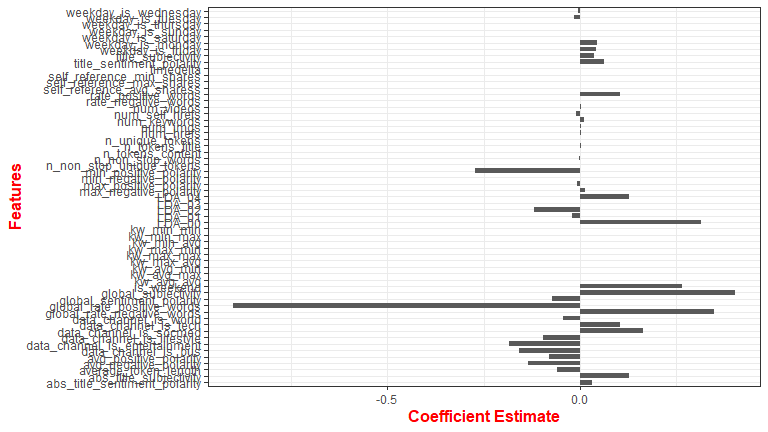

```r
cf1 <- c()
cf2 <- c()
for (i in 1:59) {
    cf1 <- append(cf1, rownames(p6_lasso$beta)[i])
    cf2 <- append(cf2, unname(p6_lasso$beta)[i])
}
cf <- data.frame(cf1, cf2)
ggplot(data = cf, aes(x = cf1, y = cf2)) + geom_bar(stat = "identity",
    width = 0.75) + coord_flip() + labs(x = "Features", y = "Coefficient Estimate") +
    theme_bw() + theme(plot.title = element_text(hjust = 0.5),
    axis.title.x = element_text(face = "bold", colour = "red",
        size = 12), axis.title.y = element_text(face = "bold",
        colour = "red", size = 12))
```

```r
# variable we chose is global_rate_positive_words (46th
# var) since its absolute value of coefficient is biggest
# p6_cv_lasso_op <-
# cv.glmnet(x=data.matrix(stest_df_p6[,46]), y=p6_y,
# family='gaussian', alpha=1, nfolds=10,
# type.measure='mse') p6_lasso_op <-
# glmnet(x=data.matrix(stest_df_p6[,46]), y=p6_y,
# family='gaussian', alpha=1,
# lambda=p6_cv_lasso_op$lambda.min)
```

While we found that, according to LASSO, “global_rate_positive_words” is a good variable, we cannot run LASSO model based on only this one variable. Since for other models, we would use a for loop to test all variables, LASSO cannot help us with variable selection. For the same reason, we will not use Ridge.

### Polynomial Expansion

We continue to use strain_df_p6 and stest_df_p6

```r
# We choose LOOCV as there is less worry about bias and
# variance than other approaches and it's asymptotically
# unbiased for the in-sample EPE.

# select variable based on in sample EPE
lm_pred_metrics <- function(fit_model) {
    LOOCV <- mean((fit_model$residuals/(1 - hatvalues(fit_model)))^2)
    return(LOOCV)
}
# exclude binary variables and variables with small number
# of possible values since degree of polynomial cannot
# exceed number of possible values
index <- c(1:3, 7:12, 19:30, 39:59)
p6_poly_mse <- c()
p6_poly_deg <- c()
for (i in index) {
    p6_poly_1 <- lm(strain_df_p6$shares ~ poly(strain_df_p6[,
        i], 1))
    p6_poly_2 <- lm(strain_df_p6$shares ~ poly(strain_df_p6[,
        i], 2))
    p6_poly_3 <- lm(strain_df_p6$shares ~ poly(strain_df_p6[,
        i], 3))
    p6_poly_4 <- lm(strain_df_p6$shares ~ poly(strain_df_p6[,
        i], 4))
    p6_poly_5 <- lm(strain_df_p6$shares ~ poly(strain_df_p6[,
        i], 5))
    p6_poly_6 <- lm(strain_df_p6$shares ~ poly(strain_df_p6[,
        i], 6))
    p6_poly_7 <- lm(strain_df_p6$shares ~ poly(strain_df_p6[,
        i], 7))
    p6_poly_8 <- lm(strain_df_p6$shares ~ poly(strain_df_p6[,
        i], 8))
    p6_poly_df <- cbind(lm_pred_metrics(p6_poly_1), lm_pred_metrics(p6_poly_2),
        lm_pred_metrics(p6_poly_3), lm_pred_metrics(p6_poly_4),
        lm_pred_metrics(p6_poly_5), lm_pred_metrics(p6_poly_6),
        lm_pred_metrics(p6_poly_7), lm_pred_metrics(p6_poly_8))
    p6_poly_mse <- c(p6_poly_mse, min(p6_poly_df))
    p6_poly_deg <- c(p6_poly_deg, which.min(p6_poly_df))
}
p6_poly <- data.frame(mse = p6_poly_mse, degree = p6_poly_deg)
which.min(p6_poly$mse)  #18th obs. in p6_poly df
```

```
## [1] 18
```

```r
min(p6_poly$mse)  #lowest mse is 0.8092535, degree is 7.
```

```
## [1] 0.8092535
```

```r
index[which.min(p6_poly$mse)]  #27th variable in strain_df_p6, which is kw_avg_avg
```

```
## [1] 27
```

From above, we see that, if we were to use a polynomial model, we would use variable “kw_avg_avg” and set function degree to be 7.

```r
# in sample EPE is:
p6_poly_optimal <- lm(data = strain_df_p6, shares ~ poly(kw_avg_avg,
    7))
p6_poly_in <- lm_pred_metrics(p6_poly_optimal)
p6_poly_in
```

```
## [1] 0.8092535
```

```r
# out of sample EPE is:
p6_poly_pred <- p6_poly_optimal %>%
    predict(stest_df_p6)
p6_poly_out <- mse(p6_poly_pred, stest_df_p6$shares)
p6_poly_out
```

```
## [1] 0.8137486
```

```r
# compile into final result
p6_poly_result <- data.frame(model = "Polynomial_deg_7", var = "kw_avg_avg",
    mse_out = p6_poly_out, mse_in = p6_poly_in)
p6_result <- rbind(p6_result, p6_poly_result)
p6_result
```

| model | var | mse_out | mse_in |
| --- | --- | --- | --- |
| KNN | kw_avg_avg | 0.8152503 | 0.8047922 |
| Polynomial_deg_7 | kw_avg_avg | 0.8137486 | 0.8092535 |

### Spline

We continue to use strain_df_p6 and stest_df_p6

```r
strain_df_p6 <- as.data.frame(strain_df_p6)
stest_df_p6 <- as.data.frame(stest_df_p6)
# in sample non-binary variables
index_nb_gam <- c(1:4, 6:12, 19:30, 39:59)
nonbinary_s <- c()
for (i in index_nb_gam) {
    p6_nb_spline_m <- gam(shares ~ s(strain_df_p6[, i]), data = strain_df_p6,
        family = gaussian())
    nonbinary_s <- c(nonbinary_s, p6_nb_spline_m$gcv.ubre.dev)
}
min(nonbinary_s)  #0.805739
```

```
## [1] 0.805739
```

```r
index_nb_gam[which.min(nonbinary_s)]  #27th variable is kw_avg_avg (seems to be better candidate)
```

```
## [1] 27
```

```r
# binary variables
index_b_gam <- c(5, 13:18, 31:38)
binary_s <- c()
for (i in index_b_gam) {
    p6_b_spline_m <- gam(shares ~ strain_df_p6[, i], data = strain_df_p6,
        family = gaussian())
    binary_s <- c(binary_s, p6_b_spline_m$gcv.ubre.dev)
}
min(binary_s)  #0.8459762
```

```
## [1] 0.8459762
```

```r
# since non-binary performs better based on in sample EPE,
# we use kw_avg_avg for spline
p6_spline_optimal <- gam(shares ~ s(kw_avg_avg), data = strain_df_p6,
    family = gaussian())
p6_spline_in <- p6_spline_optimal$gcv.ubre.dev
p6_spline_in
```

```
## [1] 0.805739
```

```r
# out of sample
p6_spline_out <- mse(stest_df_p6$shares, predict.gam(p6_spline_optimal,
    stest_df_p6))
p6_spline_out
```

```
## [1] 0.8149446
```

```r
# compile into final result
p6_spline_result <- data.frame(model = "Spline", var = "kw_avg_avg",
    mse_out = p6_spline_out, mse_in = p6_spline_in)
p6_result <- rbind(p6_result, p6_spline_result)
p6_result
```

| model | var | mse_out | mse_in |
| --- | --- | --- | --- |
| KNN | kw_avg_avg | 0.8152503 | 0.8047922 |
| Polynomial_deg_7 | kw_avg_avg | 0.8137486 | 0.8092535 |
| Spline | kw_avg_avg | 0.8149446 | 0.8057390 |

### Random Forest

```r
# pick best variable
RF_model_1 <- ranger(data = strain_df_p6, formula = shares ~
    ., mtry = 1, num.trees = 1000, importance = "permutation")
varImportance1 <- data.frame(var_importance = RF_model_1$variable.importance)
arrange(varImportance1, desc(var_importance))  #most important variable is kw_avg_avg
```

|  | var_importance |
| --- | --- |
| kw_avg_avg | 0.0213063 |
| rate_positive_words | 0.0158230 |
| kw_max_avg | 0.0155033 |
| n_non_stop_words | 0.0151467 |
| self_reference_avg_sharess | 0.0147311 |
| rate_negative_words | 0.0143547 |
| n_tokens_content | 0.0142017 |
| kw_min_avg | 0.0138758 |
| self_reference_min_shares | 0.0138147 |
| n_unique_tokens | 0.0135945 |
| LDA_02 | 0.0135293 |
| self_reference_max_shares | 0.0126926 |
| n_non_stop_unique_tokens | 0.0124717 |
| LDA_03 | 0.0109645 |
| kw_avg_max | 0.0109374 |
| global_sentiment_polarity | 0.0108673 |
| timedelta | 0.0106316 |
| kw_min_min | 0.0105422 |
| data_channel_is_world | 0.0102460 |
| min_negative_polarity | 0.0098937 |
| num_hrefs | 0.0095863 |
| num_imgs | 0.0094464 |
| LDA_04 | 0.0094008 |
| global_rate_positive_words | 0.0092463 |
| kw_min_max | 0.0091790 |
| LDA_00 | 0.0090625 |
| num_keywords | 0.0089252 |
| global_rate_negative_words | 0.0083792 |
| max_positive_polarity | 0.0083045 |
| LDA_01 | 0.0076527 |
| kw_avg_min | 0.0075414 |
| data_channel_is_entertainment | 0.0075016 |
| avg_negative_polarity | 0.0073253 |
| average_token_length | 0.0068609 |
| kw_max_min | 0.0068166 |
| global_subjectivity | 0.0065771 |
| avg_positive_polarity | 0.0064281 |
| kw_max_max | 0.0060564 |
| data_channel_is_tech | 0.0058950 |
| min_positive_polarity | 0.0056838 |
| num_self_hrefs | 0.0056017 |
| data_channel_is_bus | 0.0053534 |
| max_negative_polarity | 0.0051322 |
| abs_title_sentiment_polarity | 0.0050585 |
| title_subjectivity | 0.0049693 |
| is_weekend | 0.0048595 |
| num_videos | 0.0040136 |
| title_sentiment_polarity | 0.0039914 |
| abs_title_subjectivity | 0.0037353 |
| data_channel_is_socmed | 0.0034600 |
| weekday_is_sunday | 0.0020122 |
| weekday_is_saturday | 0.0019004 |
| data_channel_is_lifestyle | 0.0015775 |
| n_tokens_title | 0.0013989 |
| weekday_is_tuesday | 0.0005838 |
| weekday_is_wednesday | 0.0004923 |
| weekday_is_friday | 0.0004011 |
| weekday_is_thursday | 0.0003456 |
| weekday_is_monday | 0.0000992 |

```r
# RF model
p6_rf_train <- strain_df_p6 %>%
    select(kw_avg_avg, shares)
p6_rf_test <- stest_df_p6 %>%
    select(kw_avg_avg, shares)
RFmodel_p6 <- ranger(data = p6_rf_train, formula = shares ~ .,
    mtry = 1, num.trees = 1000)
# OOB
OOB_p6 <- RFmodel_p6$prediction.error
# out of sample MSE
p6_RF_out <- mse(predict(RFmodel_p6, data = p6_rf_test)$predictions,
    p6_rf_test$shares)
p6_RF_result <- data.frame(model = "Random Forest", var = "kw_avg_avg",
    mse_out = p6_RF_out, mse_in = OOB_p6)
p6_result <- rbind(p6_result, p6_RF_result)
p6_result
```

| model | var | mse_out | mse_in |
| --- | --- | --- | --- |
| KNN | kw_avg_avg | 0.8152503 | 0.8047922 |
| Polynomial_deg_7 | kw_avg_avg | 0.8137486 | 0.8092535 |
| Spline | kw_avg_avg | 0.8149446 | 0.8057390 |
| Random Forest | kw_avg_avg | 1.0887493 | 1.0783946 |

### Conclusion and Plot

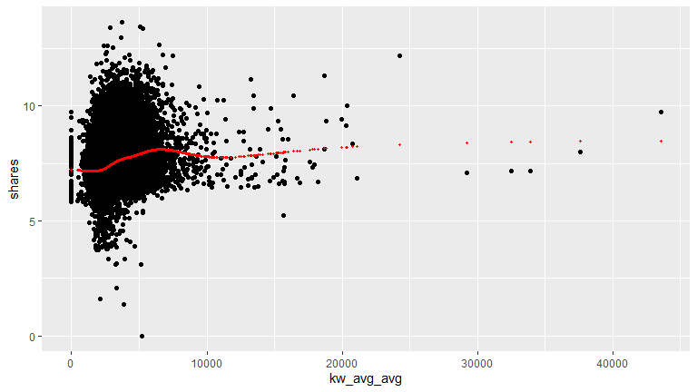

```r
p6_optimal <- gam(shares ~ s(kw_avg_avg), data = strain_df_p6,
    family = gaussian())
# training set
ggplot(data = strain_df_p6, aes(x = kw_avg_avg, y = shares)) +
    geom_point() + geom_point(size = 0.8, aes(x = kw_avg_avg,
    y = p6_optimal$fitted.values), color = "red")
```

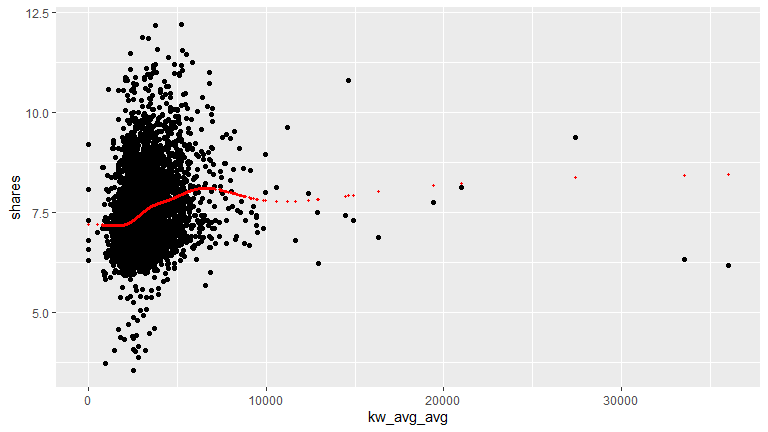

```r
# test set
p6_pred <- predict(p6_optimal, newdata = stest_df_p6)
ggplot(data = stest_df_p6, aes(x = kw_avg_avg, y = shares)) +
    geom_point() + geom_point(size = 0.8, aes(x = kw_avg_avg,
    y = p6_pred), color = "red")
```

CSV:

```r
p6PredShares <- predict(p6_optimal, newdata = test_df)
p6outPutFile <- data.frame(ID = test_df$ID, shares_Pred = p6PredShares)
# save the .csv
write.csv(p6outPutFile, "Midterm1Q6_Predictions.csv", row.names = FALSE)
```

## Question 7 - Do your models perform well on out-of-sample data? (10 pts.)

For each model, I’ll compute a root mean squared prediction error using your submitted predictions and the true log number of shares for the articles in the hidden test set. Across all models turned in, points will be allocated as follows:

1. For Q1 and Q3, let $\text{RMSE}_{\text{Min}}$ be the minimum prediction error over the submitted models. Let $\text{RMSE}_i$ be your predictive error. Your prediction points will be computed as:

$$4 \times
\frac{\text{RMSE}_{\text{Min}}}{\text{RMSE}_{i}}$$

$$2 \times
\frac{\text{RMSE}_{\text{Min}}}{\text{RMSE}_{i}}$$

The goal here is to add a low-stakes incentive and fun “competition” to try to optimize your predictive models. **I expect that the performance across groups/students will be quite close, so this won’t greatly affect your final grade.**